# Kaggle Ames House Prices

This project aims to create some regression models to predict the sale price of each home in Ames, Lowa. The dataset was collected from Kaggle competition website (https://www.kaggle.com/c/house-prices-advanced-regression-techniques), which includes 1460 observations and 81 variables that cover all aspects of residential homes. The complete code can be found [here](https://github.com/Erica-Tan/House-Prices).

We are interested to know:

- Which neighborhood is most popular to live in?
- Which neighborhood in Ames has the most expensive home of all?
- Which residential home has the best value for money?
- What are the contributing factors to soaring housing price?

The output of the solution will give useful insights to any residential selling business in terms of market trend, price planning, and customized marketing and selling. Relevant businesses can take full advantage of the model and build better industry applications.

Before we get started, let’s first import all of the functions and classes we intend to use.

```python
import os
import pandas as pd
import numpy as np
import matplotlib.pyplot as plt
import seaborn as sns
from scipy import stats
from datetime import date
from sklearn.model_selection import train_test_split
from sklearn.preprocessing import MinMaxScaler
from sklearn.metrics import mean_squared_error
from sklearn.model_selection import GridSearchCV
from sklearn.feature_selection import SelectFromModel
from sklearn.externals import joblib
import xgboost as xgb
from xgboost import plot_tree

os.chdir("D:/Python/House-Prices")
```

```python
# Load data
df_data = pd.read_csv("data/train.csv")
```

```python
df_data.head()
```

|  | Id | MSSubClass | MSZoning | LotFrontage | LotArea | Street | Alley | LotShape | LandContour | Utilities | ... | PoolArea | PoolQC | Fence | MiscFeature | MiscVal | MoSold | YrSold | SaleType | SaleCondition | SalePrice |
| --- | --- | --- | --- | --- | --- | --- | --- | --- | --- | --- | --- | --- | --- | --- | --- | --- | --- | --- | --- | --- | --- |
| 0 | 1 | 60 | RL | 65.0 | 8450 | Pave | NaN | Reg | Lvl | AllPub | ... | 0 | NaN | NaN | NaN | 0 | 2 | 2008 | WD | Normal | 208500 |
| 1 | 2 | 20 | RL | 80.0 | 9600 | Pave | NaN | Reg | Lvl | AllPub | ... | 0 | NaN | NaN | NaN | 0 | 5 | 2007 | WD | Normal | 181500 |
| 2 | 3 | 60 | RL | 68.0 | 11250 | Pave | NaN | IR1 | Lvl | AllPub | ... | 0 | NaN | NaN | NaN | 0 | 9 | 2008 | WD | Normal | 223500 |
| 3 | 4 | 70 | RL | 60.0 | 9550 | Pave | NaN | IR1 | Lvl | AllPub | ... | 0 | NaN | NaN | NaN | 0 | 2 | 2006 | WD | Abnorml | 140000 |
| 4 | 5 | 60 | RL | 84.0 | 14260 | Pave | NaN | IR1 | Lvl | AllPub | ... | 0 | NaN | NaN | NaN | 0 | 12 | 2008 | WD | Normal | 250000 |

5 rows × 81 columns

## 1. Missing data

This dataset is filled with many missing values, therefore, all NA’s should be filled in with appropriate values before building any predictive model. For each column, the missing values were replaced by using features that have a strong correlation, which helps to determine what values to fill in.

```
              Total   Percent
PoolQC         1453  0.995205
MiscFeature    1406  0.963014
Alley          1369  0.937671
Fence          1179  0.807534
FireplaceQu     690  0.472603
LotFrontage     259  0.177397
GarageYrBlt      81  0.055479
GarageType       81  0.055479
GarageFinish     81  0.055479
GarageQual       81  0.055479
GarageCond       81  0.055479
BsmtFinType2     38  0.026027
BsmtExposure     38  0.026027
BsmtFinType1     37  0.025342
BsmtCond         37  0.025342
BsmtQual         37  0.025342
MasVnrArea        8  0.005479
MasVnrType        8  0.005479
Electrical        1  0.000685
```

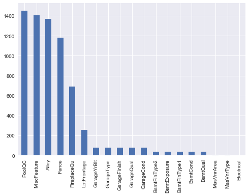

```python
missing  = df_data.isnull().sum()
missing = missing[missing > 0]
total  = missing.sort_values(ascending=False)
percent = (missing/len(df_data)).sort_values(ascending=False)
missing_data = pd.concat([total, percent], axis=1, keys=["Total", "Percent"])

print(missing_data)

#plot missing data
total.plot.bar()
plt.show()
```

Let's define a helper function to fill with missing data first.

```python
def fill_missing_data(frame, column, value = 'None', re_column='None'):
    filtered = frame[column].isnull()
    if re_column == 'None':
        frame.loc[filtered, column] = value
    else:
        frame.loc[filtered, column] = frame.loc[filtered, re_column]
```

### PoolQC

PoolQC can be filled with ‘None’ since each has a corresponding PoolArea of 0

```python
filtered = (df_data["PoolQC"].isnull())
df_data.loc[filtered,["PoolQC","PoolArea"]]
```

|  | PoolQC | PoolArea |
| --- | --- | --- |
| 0 | NaN | 0 |
| 1 | NaN | 0 |
| 2 | NaN | 0 |
| 3 | NaN | 0 |
| 4 | NaN | 0 |
| 5 | NaN | 0 |
| 6 | NaN | 0 |
| 7 | NaN | 0 |
| 8 | NaN | 0 |
| 9 | NaN | 0 |
| 10 | NaN | 0 |
| 11 | NaN | 0 |
| 12 | NaN | 0 |
| 13 | NaN | 0 |
| 14 | NaN | 0 |
| 15 | NaN | 0 |
| 16 | NaN | 0 |
| 17 | NaN | 0 |
| 18 | NaN | 0 |
| 19 | NaN | 0 |
| 20 | NaN | 0 |
| 21 | NaN | 0 |
| 22 | NaN | 0 |
| 23 | NaN | 0 |
| 24 | NaN | 0 |
| 25 | NaN | 0 |
| 26 | NaN | 0 |
| 27 | NaN | 0 |
| 28 | NaN | 0 |
| 29 | NaN | 0 |
| ... | ... | ... |
| 1430 | NaN | 0 |
| 1431 | NaN | 0 |
| 1432 | NaN | 0 |
| 1433 | NaN | 0 |
| 1434 | NaN | 0 |
| 1435 | NaN | 0 |
| 1436 | NaN | 0 |
| 1437 | NaN | 0 |
| 1438 | NaN | 0 |
| 1439 | NaN | 0 |
| 1440 | NaN | 0 |
| 1441 | NaN | 0 |
| 1442 | NaN | 0 |
| 1443 | NaN | 0 |
| 1444 | NaN | 0 |
| 1445 | NaN | 0 |
| 1446 | NaN | 0 |
| 1447 | NaN | 0 |
| 1448 | NaN | 0 |
| 1449 | NaN | 0 |
| 1450 | NaN | 0 |
| 1451 | NaN | 0 |
| 1452 | NaN | 0 |
| 1453 | NaN | 0 |
| 1454 | NaN | 0 |
| 1455 | NaN | 0 |
| 1456 | NaN | 0 |
| 1457 | NaN | 0 |
| 1458 | NaN | 0 |
| 1459 | NaN | 0 |

1453 rows × 2 columns

```python
fill_missing_data(df_data, "PoolQC", "None")
```

### GarageType / GarageYrBlt / GarageFinish / GarageCars / GarageArea / GarageQual / GarageCond

For the garage attributes, we can check to see that if the missing recordes have 0 GarageArea and 0 GarageCars. If they do, we can fill in them with 'None' or '0' since having 0 area and 0 cars in their garage will imply that they do not have any at all.

```python
garage_cols=["GarageType","GarageYrBlt","GarageFinish","GarageCars","GarageArea","GarageQual","GarageCond"]

filtered = df_data[garage_cols].isnull().apply(lambda x: any(x), axis=1)

df_data.loc[filtered, garage_cols]
```

|  | GarageType | GarageYrBlt | GarageFinish | GarageCars | GarageArea | GarageQual | GarageCond |
| --- | --- | --- | --- | --- | --- | --- | --- |
| 39 | NaN | NaN | NaN | 0 | 0 | NaN | NaN |
| 48 | NaN | NaN | NaN | 0 | 0 | NaN | NaN |
| 78 | NaN | NaN | NaN | 0 | 0 | NaN | NaN |
| 88 | NaN | NaN | NaN | 0 | 0 | NaN | NaN |
| 89 | NaN | NaN | NaN | 0 | 0 | NaN | NaN |
| 99 | NaN | NaN | NaN | 0 | 0 | NaN | NaN |
| 108 | NaN | NaN | NaN | 0 | 0 | NaN | NaN |
| 125 | NaN | NaN | NaN | 0 | 0 | NaN | NaN |
| 127 | NaN | NaN | NaN | 0 | 0 | NaN | NaN |
| 140 | NaN | NaN | NaN | 0 | 0 | NaN | NaN |
| 148 | NaN | NaN | NaN | 0 | 0 | NaN | NaN |
| 155 | NaN | NaN | NaN | 0 | 0 | NaN | NaN |
| 163 | NaN | NaN | NaN | 0 | 0 | NaN | NaN |
| 165 | NaN | NaN | NaN | 0 | 0 | NaN | NaN |
| 198 | NaN | NaN | NaN | 0 | 0 | NaN | NaN |
| 210 | NaN | NaN | NaN | 0 | 0 | NaN | NaN |
| 241 | NaN | NaN | NaN | 0 | 0 | NaN | NaN |
| 250 | NaN | NaN | NaN | 0 | 0 | NaN | NaN |
| 287 | NaN | NaN | NaN | 0 | 0 | NaN | NaN |
| 291 | NaN | NaN | NaN | 0 | 0 | NaN | NaN |
| 307 | NaN | NaN | NaN | 0 | 0 | NaN | NaN |
| 375 | NaN | NaN | NaN | 0 | 0 | NaN | NaN |
| 386 | NaN | NaN | NaN | 0 | 0 | NaN | NaN |
| 393 | NaN | NaN | NaN | 0 | 0 | NaN | NaN |
| 431 | NaN | NaN | NaN | 0 | 0 | NaN | NaN |
| 434 | NaN | NaN | NaN | 0 | 0 | NaN | NaN |
| 441 | NaN | NaN | NaN | 0 | 0 | NaN | NaN |
| 464 | NaN | NaN | NaN | 0 | 0 | NaN | NaN |
| 495 | NaN | NaN | NaN | 0 | 0 | NaN | NaN |
| 520 | NaN | NaN | NaN | 0 | 0 | NaN | NaN |
| ... | ... | ... | ... | ... | ... | ... | ... |
| 954 | NaN | NaN | NaN | 0 | 0 | NaN | NaN |
| 960 | NaN | NaN | NaN | 0 | 0 | NaN | NaN |
| 968 | NaN | NaN | NaN | 0 | 0 | NaN | NaN |
| 970 | NaN | NaN | NaN | 0 | 0 | NaN | NaN |
| 976 | NaN | NaN | NaN | 0 | 0 | NaN | NaN |
| 1009 | NaN | NaN | NaN | 0 | 0 | NaN | NaN |
| 1011 | NaN | NaN | NaN | 0 | 0 | NaN | NaN |
| 1030 | NaN | NaN | NaN | 0 | 0 | NaN | NaN |
| 1038 | NaN | NaN | NaN | 0 | 0 | NaN | NaN |
| 1096 | NaN | NaN | NaN | 0 | 0 | NaN | NaN |
| 1123 | NaN | NaN | NaN | 0 | 0 | NaN | NaN |
| 1131 | NaN | NaN | NaN | 0 | 0 | NaN | NaN |
| 1137 | NaN | NaN | NaN | 0 | 0 | NaN | NaN |
| 1143 | NaN | NaN | NaN | 0 | 0 | NaN | NaN |
| 1173 | NaN | NaN | NaN | 0 | 0 | NaN | NaN |
| 1179 | NaN | NaN | NaN | 0 | 0 | NaN | NaN |
| 1218 | NaN | NaN | NaN | 0 | 0 | NaN | NaN |
| 1219 | NaN | NaN | NaN | 0 | 0 | NaN | NaN |
| 1234 | NaN | NaN | NaN | 0 | 0 | NaN | NaN |
| 1257 | NaN | NaN | NaN | 0 | 0 | NaN | NaN |
| 1283 | NaN | NaN | NaN | 0 | 0 | NaN | NaN |
| 1323 | NaN | NaN | NaN | 0 | 0 | NaN | NaN |
| 1325 | NaN | NaN | NaN | 0 | 0 | NaN | NaN |
| 1326 | NaN | NaN | NaN | 0 | 0 | NaN | NaN |
| 1337 | NaN | NaN | NaN | 0 | 0 | NaN | NaN |
| 1349 | NaN | NaN | NaN | 0 | 0 | NaN | NaN |
| 1407 | NaN | NaN | NaN | 0 | 0 | NaN | NaN |
| 1449 | NaN | NaN | NaN | 0 | 0 | NaN | NaN |
| 1450 | NaN | NaN | NaN | 0 | 0 | NaN | NaN |
| 1453 | NaN | NaN | NaN | 0 | 0 | NaN | NaN |

81 rows × 7 columns

```python
for column in garage_cols:
    if df_data.dtypes[column] == "object":
        fill_missing_data(df_data, column, "None")
    else:
        fill_missing_data(df_data, column, 0)
```

### Electrical

With only 1 missing value for Electrical. we can fill in it with the most frequent value 'SBrkr'.

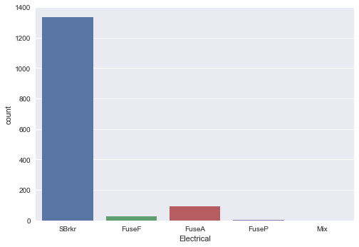

```python
sns.countplot(df_data["Electrical"])
plt.show()
```

```python
# most frequent value
fill_missing_data(df_data, "Electrical", "SBrkr")
```

### BsmtQual / BsmtCond / BsmtExposure / BsmtFinType1 / BsmtFinType2

```python
basement_cols=["BsmtQual","BsmtCond","BsmtExposure","BsmtFinType1","BsmtFinType2","BsmtFinSF1","BsmtFinSF2"]

filtered = df_data[basement_cols].isnull().apply(lambda x: any(x), axis=1)

df_data.loc[filtered, basement_cols]
```

|  | BsmtQual | BsmtCond | BsmtExposure | BsmtFinType1 | BsmtFinType2 | BsmtFinSF1 | BsmtFinSF2 |
| --- | --- | --- | --- | --- | --- | --- | --- |
| 17 | NaN | NaN | NaN | NaN | NaN | 0 | 0 |
| 39 | NaN | NaN | NaN | NaN | NaN | 0 | 0 |
| 90 | NaN | NaN | NaN | NaN | NaN | 0 | 0 |
| 102 | NaN | NaN | NaN | NaN | NaN | 0 | 0 |
| 156 | NaN | NaN | NaN | NaN | NaN | 0 | 0 |
| 182 | NaN | NaN | NaN | NaN | NaN | 0 | 0 |
| 259 | NaN | NaN | NaN | NaN | NaN | 0 | 0 |
| 332 | Gd | TA | No | GLQ | NaN | 1124 | 479 |
| 342 | NaN | NaN | NaN | NaN | NaN | 0 | 0 |
| 362 | NaN | NaN | NaN | NaN | NaN | 0 | 0 |
| 371 | NaN | NaN | NaN | NaN | NaN | 0 | 0 |
| 392 | NaN | NaN | NaN | NaN | NaN | 0 | 0 |
| 520 | NaN | NaN | NaN | NaN | NaN | 0 | 0 |
| 532 | NaN | NaN | NaN | NaN | NaN | 0 | 0 |
| 533 | NaN | NaN | NaN | NaN | NaN | 0 | 0 |
| 553 | NaN | NaN | NaN | NaN | NaN | 0 | 0 |
| 646 | NaN | NaN | NaN | NaN | NaN | 0 | 0 |
| 705 | NaN | NaN | NaN | NaN | NaN | 0 | 0 |
| 736 | NaN | NaN | NaN | NaN | NaN | 0 | 0 |
| 749 | NaN | NaN | NaN | NaN | NaN | 0 | 0 |
| 778 | NaN | NaN | NaN | NaN | NaN | 0 | 0 |
| 868 | NaN | NaN | NaN | NaN | NaN | 0 | 0 |
| 894 | NaN | NaN | NaN | NaN | NaN | 0 | 0 |
| 897 | NaN | NaN | NaN | NaN | NaN | 0 | 0 |
| 948 | Gd | TA | NaN | Unf | Unf | 0 | 0 |
| 984 | NaN | NaN | NaN | NaN | NaN | 0 | 0 |
| 1000 | NaN | NaN | NaN | NaN | NaN | 0 | 0 |
| 1011 | NaN | NaN | NaN | NaN | NaN | 0 | 0 |
| 1035 | NaN | NaN | NaN | NaN | NaN | 0 | 0 |
| 1045 | NaN | NaN | NaN | NaN | NaN | 0 | 0 |
| 1048 | NaN | NaN | NaN | NaN | NaN | 0 | 0 |
| 1049 | NaN | NaN | NaN | NaN | NaN | 0 | 0 |
| 1090 | NaN | NaN | NaN | NaN | NaN | 0 | 0 |
| 1179 | NaN | NaN | NaN | NaN | NaN | 0 | 0 |
| 1216 | NaN | NaN | NaN | NaN | NaN | 0 | 0 |
| 1218 | NaN | NaN | NaN | NaN | NaN | 0 | 0 |
| 1232 | NaN | NaN | NaN | NaN | NaN | 0 | 0 |
| 1321 | NaN | NaN | NaN | NaN | NaN | 0 | 0 |
| 1412 | NaN | NaN | NaN | NaN | NaN | 0 | 0 |

For rows 948, the only missing value is from BsmtExposure attribute, we can fill in 'No' as that is the most frequent value and this house most likely don’t have any exposure for its basement.

```python
df_data.loc[948, "BsmtExposure"] = "No"
```

```python
grouped = df_data.groupby("BsmtFinType2")
grouped = grouped["BsmtFinSF2"].agg(np.mean)
print(grouped)

df_data.loc[332, "BsmtFinType2"] = "LwQ"
```

```
BsmtFinType2
ALQ    626.157895
BLQ    329.909091
GLQ    658.000000
LwQ    310.739130
Rec    392.462963
Unf      0.000000
Name: BsmtFinSF2, dtype: float64
```

The rest of the basement columns corresponding to area will be filled with '0' since they likely don’t have a basement and the categoric missing values will be filled with 'None'.

```python
for column in basement_cols:
    if df_data.dtypes[column] == "object":
        fill_missing_data(df_data, column, "None")
    else:
        fill_missing_data(df_data, column, 0)
```

### MasVnrType / MasVnrArea

We can see if both missing values come from the same houses. For houses with NA’s on both columns, we can fill '0' for the area and 'None' for the type since they likely do not have a masonry veneer.

```python
filtered = (df_data["MasVnrType"].isnull()) | (df_data["MasVnrArea"].isnull())
df_data.loc[filtered,["MasVnrType","MasVnrArea"]]
```

|  | MasVnrType | MasVnrArea |
| --- | --- | --- |
| 234 | NaN | NaN |
| 529 | NaN | NaN |
| 650 | NaN | NaN |
| 936 | NaN | NaN |
| 973 | NaN | NaN |
| 977 | NaN | NaN |
| 1243 | NaN | NaN |
| 1278 | NaN | NaN |

```python
fill_missing_data(df_data, "MasVnrType", "None")
fill_missing_data(df_data, "MasVnrArea", 0)
```

### LotFrontage

```python
grouped = df_data.groupby("Neighborhood")
grouped = grouped["LotFrontage"].agg(np.mean)
print(grouped)
```

```
Neighborhood
Blmngtn    47.142857
Blueste    24.000000
BrDale     21.562500
BrkSide    57.509804
ClearCr    83.461538
CollgCr    71.682540
Crawfor    71.804878
Edwards    68.217391
Gilbert    79.877551
IDOTRR     62.500000
MeadowV    27.800000
Mitchel    70.083333
NAmes      76.462366
NPkVill    32.285714
NWAmes     81.288889
NoRidge    91.878788
NridgHt    81.881579
OldTown    62.788991
SWISU      58.913043
Sawyer     74.437500
SawyerW    71.500000
Somerst    64.666667
StoneBr    62.700000
Timber     80.133333
Veenker    59.714286
Name: LotFrontage, dtype: float64
```

```python
filtered = df_data["LotFrontage"].isnull()
df_data.loc[filtered,"LotFrontage"] = df_data.loc[filtered,"Neighborhood"].map(lambda neighbor : grouped[neighbor])
```

### Fence / MiscFeature

The missing values for Fence and MiscFeature can be repalced with ‘None’ as they probably don’t have this feature with their property.

```python
fill_missing_data(df_data, "Fence", "None")
fill_missing_data(df_data, "MiscFeature", "None")
```

### FireplaceQu

Let's check to see if any of the missing values for FireplaceQu come from houses that recorded having at least 1 fireplace

```python
filtered = (df_data["Fireplaces"] > 0) & (df_data["FireplaceQu"].isnull())
len(df_data.loc[filtered,["Fireplaces","FireplaceQu"]])
```

```
0
```

All the houses that have missing values did not recorded having any fireplaces. We can simply replace the NA’s with ‘None’ since these houses don’t have any fireplaces at all.

```python
fill_missing_data(df_data, "FireplaceQu", "None")
```

### Alley

```python
fill_missing_data(df_data, "Alley", "None")
```

## 2. Feature construction

```python
#split data into two train and test
train, test = train_test_split(df_data, test_size = 0.2, random_state=42)
```

Some numerical features are actually really categories

```python
df_data = df_data.replace({"MSSubClass" : {20 : "SC20", 30 : "SC30", 40 : "SC40", 45 : "SC45",
                                       50 : "SC50", 60 : "SC60", 70 : "SC70", 75 : "SC75",
                                       80 : "SC80", 85 : "SC85", 90 : "SC90", 120 : "SC120",
                                       150 : "SC150", 160 : "SC160", 180 : "SC180", 190 : "SC190"},
                           "OverallQual" : {10 : "Ve", 9 : "Ex", 8 : "Vg" , 7 : "Gd", 6 : "AA",
                                        5 : "TA", 4 : "BA" , 3 : "Fa", 2 : "Po", 1 : "Vp"},
                           "OverallCond" : {10 : "Ve", 9 : "Ex", 8 : "Vg" , 7 : "Gd", 6 : "AA",
                                        5 : "TA", 4 : "BA" , 3 : "Fa", 2 : "Po", 1 : "Vp"}
                           })
```

### Year / Month

```python
# records that a house was remodelled if the year it was built is different than the remodel year.
df_data["Remodeled"] = (df_data["YearRemodAdd"] != df_data["YearBuilt"]) * 1

# if the houses have been recently remodelled
df_data["RecentRemodel"] = (df_data["YearRemodAdd"] == df_data["YrSold"]) * 1

# Was this house sold in the year it was built?
df_data["NewHouse"] = (df_data["YearBuilt"] == df_data["YrSold"]) * 1

# how old a house is
df_data["HouseAge"] = date.today().year - df_data["YearBuilt"]

# how long ago the house was sold
df_data["TimeSinceSold"] = date.today().year - df_data["YrSold"]

# how many years since the house was remodelled and sold
df_data["YearSinceRemodel"] = df_data["YrSold"] - df_data["YearRemodAdd"]
```

The following graph shows that the largest proportion of houses sold is during the summer months: May, June, July. Let’s add a column that seperates the the summer houses from the rest.

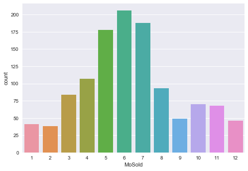

```python
sns.countplot(train["MoSold"])
plt.show()

df_data["HighSeason"] = (df_data["MoSold"].isin([5,6,7])) * 1
```

### Area features

```python
area_columns = ["LotFrontage", "LotArea", "MasVnrArea", "BsmtFinSF1", "BsmtFinSF2", "BsmtUnfSF",
             "TotalBsmtSF", "1stFlrSF", "2ndFlrSF", "GrLivArea", "GarageArea", "WoodDeckSF",
             "OpenPorchSF", "EnclosedPorch", "3SsnPorch", "ScreenPorch", "LowQualFinSF", "PoolArea"]

df_data["TotalArea"] = df_data[area_columns].sum(axis =1)


df_data["HasLowQualArea"] = (df_data["LowQualFinSF"] > 0) * 1
df_data["HasBasement"] = (df_data["TotalBsmtSF"] > 0) * 1
df_data["HasGarage"] = (df_data["GarageArea"] > 0) * 1
df_data["Has2ndFloor"] = (df_data["2ndFlrSF"] > 0) * 1
df_data["HasMasVnr"] = (df_data["MasVnrArea"] > 0) * 1
df_data["HasWoodDeck"] = (df_data["WoodDeckSF"] > 0) * 1
df_data["HasOpenPorch"] = (df_data["OpenPorchSF"] > 0) * 1
df_data["HasScreenPorch"] = (df_data["ScreenPorch"] > 0) * 1
df_data["HasEnclosedPorch"] = (df_data["EnclosedPorch"] > 0) * 1
df_data["Has3SsnPorch"] = (df_data["3SsnPorch"] > 0) * 1
df_data["HasPool"] = (df_data["PoolArea"] > 0) * 1
```

### Neighborhood

```
d:\program files\python\python36\lib\site-packages\seaborn\categorical.py:342: DeprecationWarning: pandas.core.common.is_categorical_dtype is deprecated. import from the public API: pandas.api.types.is_categorical_dtype instead
  elif is_categorical(y):
```

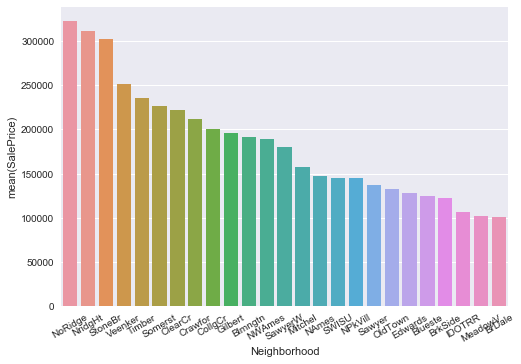

```python
grouped = grouped = train[["Neighborhood", 'SalePrice']].groupby("Neighborhood").mean()
grouped = grouped.sort_values(by='SalePrice', ascending=0)
grouped = grouped.reset_index(level=0)

sns.barplot(grouped["Neighborhood"], grouped["SalePrice"])
plt.xticks(rotation=30)
plt.show()

#one-hot encode the more expensive neighborhoods
nbrh_rich = ["NridgeHt", "NoRidge", "StoneBr", "Veenker", "Timber", "Somerst"]
df_data["NbrhRich"] = df_data["Neighborhood"].apply(lambda x: 1 if x in nbrh_rich else 0)
```

### SalePrice

The distribution of SalePrice is skewed. So it will be transformed later

```
count      1168.000000
mean     181441.541952
std       77263.583862
min       34900.000000
25%      130000.000000
50%      165000.000000
75%      214925.000000
max      745000.000000
Name: SalePrice, dtype: float64
```

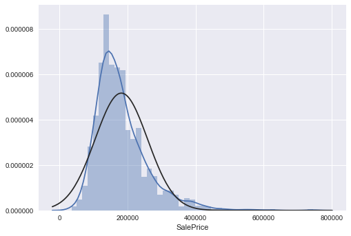

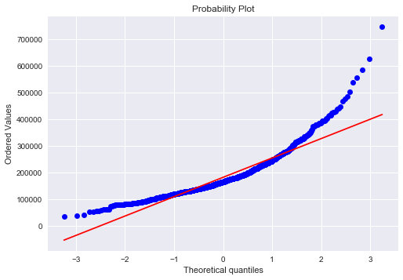

```
Skewness: 1.743129
Kurtosis: 5.475315
```

```python
#descriptive statistics summary
print (train["SalePrice"].describe())

#histogram
# 1. Deviate from the normal distribution.
# 2. Have appreciable positive skewness.
# 3. Show peakedness.
sns.distplot(train["SalePrice"], fit=stats.norm)
plt.show()

#normal probability plot
res = stats.probplot(train["SalePrice"], plot=plt)
plt.show()

#skewness and kurtosis
print("Skewness: %f" % train["SalePrice"].skew())
print("Kurtosis: %f" % train["SalePrice"].kurt())
```

### Remove columns

Utilities only has 1 value for 'NoSeWa' and the rest are 'AllPub'. We can drop this feature from our dataset as the house with 'NoSeWa' is from our training set and will not have any effect on predictive modelling.

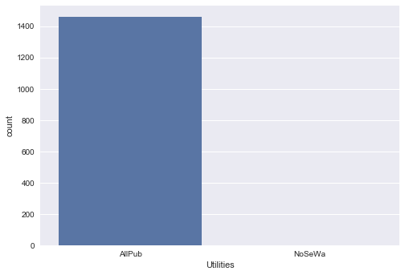

```python
sns.countplot(df_data["Utilities"])
plt.show()
```

For date attribures, since we have constructed some features based on these features, we removed the original attributes. Garage area is strongly correlated with number of cars, so we can remove 'GarageCars'. "1stFlrSF" amd "2ndFlrSF attributes can also be removed as 1stFlrSF + 2nFlrSF + LowQualFinSF = GrLivArea.

```python
del_columns = ["Utilities", "GarageCars", "1stFlrSF", "2ndFlrSF", "YearBuilt",
               "YearRemodAdd", "YrSold", "MoSold", "GarageYrBlt", "Id"]

df_data = df_data.drop(del_columns, axis=1)
```

## 3. Dummy encoding

Before performing dummy, numeric columns are recorded for later use.

```python
num_columns = df_data.select_dtypes(include = ["float64", "int64"]).columns.values.tolist()
num_columns.remove("SalePrice")

# one hot encoding for categorical data
df_data = pd.get_dummies(df_data)
```

## 4. Log transform

Transforming the skewed numeric features by taking log(feature + 1) will make the features more normal.

Some independent variables look like good candidates for log transformation, such asTotalBsmtSF, KitchenAbvGr, LotFrontage, LotArea and others. While ganining on regression transformation will smooth out some irregularities which could be important, such as 2ndFlrSF. These irregularities are good candidates for feature construction.

```python
# log the attributes that follow the normal distribute
log_columns = ["LotFrontage", "LotArea","BsmtUnfSF",
               "TotalBsmtSF", "GrLivArea", "TotalArea", "SalePrice"]

# Transform the skewed numeric features by taking log(feature + 1).
# This will make the features more normal.
skewed = df_data[log_columns].apply(lambda x: x.dropna().astype(float).skew())
skewed = skewed[(skewed > 0.8) | (skewed < -0.8)]
skewed = skewed.index.tolist()

pd.options.mode.chained_assignment = None
df_data.loc[:,skewed] = np.log1p(df_data[skewed].values)
```

## 4. Normalization

An important concern with this dataset is that the input attributes all vary in their scales because they measure different quantities. It is almost always good practice to normalized the data before buliding model.

```python
# split the dataset into dataset 80% and test 20%
train, test = train_test_split(df_data, test_size = 0.2, random_state=42)

min_max = MinMaxScaler()
train.loc[:,num_columns] = min_max.fit_transform(train[num_columns])
test.loc[:,num_columns] = min_max.fit_transform(test[num_columns])
```

## 5. Build model - XGBoost

```python
df_data = train

# split train dataset into train and validation
train, validation = train_test_split(train, test_size=0.2, random_state=42)

# split into input (X) and output (Y) variables
y_train = train['SalePrice']
x_train = train.drop('SalePrice', axis=1)
y_validation = validation['SalePrice']
x_validation = validation.drop('SalePrice', axis=1)
Y = df_data['SalePrice']
X = df_data.drop('SalePrice', axis=1)
```

### Baseline model

Baseline model provides a point of comparison for the model that will be evaluated later. We can also specify an evaluation metric and set the early_stopping_rounds parameter to stop training once no further improvements have been made to the model.

```python
# Baseline model
model = xgb.XGBRegressor(
     learning_rate =0.1,
     n_estimators=1000,
     max_depth=5,
     min_child_weight=2,
     gamma=0,
     subsample=0.8,
     colsample_bytree=0.8,
     n_jobs=2,
     scale_pos_weight=1,
     random_state=42)

early_stopping_rounds = 10

#Fit the algorithm on the data
eval_set = [(x_validation, y_validation)]
model.fit(x_train, y_train, early_stopping_rounds=early_stopping_rounds, eval_metric='rmse', eval_set=eval_set, verbose=False)

# make predictions for train data
y_train_pred = model.predict(x_train)
y_train_pred = [value for value in y_train_pred]
# evaluate predictions
y_train_true = np.expm1(y_train.values)
y_train_pred = np.expm1(y_train_pred)
print("train RMSE: %f" % (np.sqrt(mean_squared_error(y_train_true, y_train_pred))))

# make predictions for validation data
y_validation_pred = model.predict(x_validation)
y_validation_pred = [value for value in y_validation_pred]
# evaluate predictions
y_validation_true = np.expm1(y_validation.values)
y_validation_pred = np.expm1(y_validation_pred)
print("validation RMSE: %f" % (np.sqrt(mean_squared_error(y_validation_true, y_validation_pred))))
```

```
train RMSE: 7815.046687
validation RMSE: 25946.024074
```

### Feature importance

Feature importance provides a score that indicates how useful or valuable each feature was in the construction of the boosted decision trees within the model. The more an attribute is used to make key decisions with decision trees, the higher its relative importance.

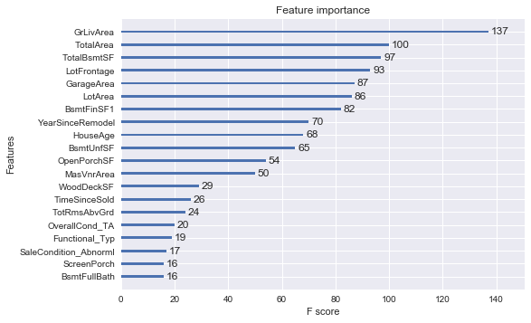

```python
#Plot important
xgb.plot_importance(model, max_num_features = 20)
plt.show()
```

### Parameter tuning

Step 1: Tune learning rate and number of estimators

```python
#Tune learning rate and number of estimators
model = xgb.XGBRegressor(
     learning_rate =0.1,
     n_estimators=1000,
     max_depth=5,
     min_child_weight=2,
     gamma=0,
     subsample=0.8,
     colsample_bytree=0.8,
     n_jobs=2,
     scale_pos_weight=1,
     random_state=42)

# define the grid search parameters
# best parameters {'n_estimators': 250 / 150, 'learning_rate': 0.1}
learning_rate = [0.01, 0.1, 0.15, 0.2, 0.25, 0.3, 0.35, 0.4]
n_estimators = range(50, 400, 50)

param_test = {
 'learning_rate': learning_rate,
  'n_estimators': n_estimators
}

gsearch = GridSearchCV(estimator=model, scoring="neg_mean_squared_error", n_jobs=-1,
                        param_grid=param_test, verbose=0)
gsearch.fit(x_train, y_train)

# summarize results
print("Best: %f using %s" % (gsearch.best_score_, gsearch.best_params_))
```

```
Best: -0.017647 using {'learning_rate': 0.1, 'n_estimators': 350}
```

Step 3: Tune max_depth and min_child_weight

```python
# Tune max_depth and min_child_weight
model = xgb.XGBRegressor(
     learning_rate=0.1,
     n_estimators=150,
     max_depth=5,
     min_child_weight=2,
     gamma=0,
     subsample=0.8,
     colsample_bytree=0.8,
     n_jobs=2,
     scale_pos_weight=1,
     random_state=42)

# define the grid search parameters
# best parameters {'min_child_weight': 5, 'max_depth': 5}
param_test = {
    'max_depth':range(3,10,2),
    'min_child_weight':range(1,6,2)
}

gsearch = GridSearchCV(estimator=model, scoring="neg_mean_squared_error", n_jobs=-1,
                        param_grid=param_test, verbose=0)
gsearch.fit(x_train, y_train)

# summarize results
print("Best: %f using %s" % (gsearch.best_score_, gsearch.best_params_))
```

```
Best: -0.017103 using {'max_depth': 5, 'min_child_weight': 5}
```

Step 3: Tune gamma

```python
# Tune gamma
model = xgb.XGBRegressor(
     learning_rate=0.1,
     n_estimators=150,
     max_depth=5,
     min_child_weight=5,
     gamma=0,
     subsample=0.8,
     colsample_bytree=0.8,
     n_jobs=2,
     scale_pos_weight=1,
     random_state=42)

# define the grid search parameters
# best parameters {'gamma': 0.0}
param_test = {
 'gamma':[i/10.0 for i in range(0,5)]
}

gsearch = GridSearchCV(estimator=model, scoring="neg_mean_squared_error", n_jobs=-1,
                        param_grid=param_test, verbose=0)
gsearch.fit(x_train, y_train)

# summarize results
print("Best: %f using %s" % (gsearch.best_score_, gsearch.best_params_))
```

```
Best: -0.017103 using {'gamma': 0.0}
```

Step 4: Tune subsample and colsample_bytree

```python
# Tune subsample and colsample_bytree
model = xgb.XGBRegressor(
     learning_rate=0.1,
     n_estimators=150,
     max_depth=5,
     min_child_weight=5,
     gamma=0,
     subsample=0.8,
     colsample_bytree=0.8,
     n_jobs=2,
     scale_pos_weight=1,
     random_state=42)

# define the grid search parameters
# best parameters {'colsample_bytree': 0.6, 'subsample': 0.8}
subsample = [i/100.0 for i in range(10,110,10)]
colsample_bytree = [i/100.0 for i in range(10,110,10)]

param_test = {
 'subsample': subsample,
 'colsample_bytree':colsample_bytree
}

gsearch = GridSearchCV(estimator=model, scoring="neg_mean_squared_error", n_jobs=-1,
                        param_grid=param_test, verbose=0)
gsearch.fit(x_train, y_train)

# summarize results
print("Best: %f using %s" % (gsearch.best_score_, gsearch.best_params_))
```

```
Best: -0.016780 using {'colsample_bytree': 0.8, 'subsample': 0.9}
```

Step 5: Tuning Regularization Parameters

```python
# Tuning Regularization Parameters
model = xgb.XGBRegressor(
     learning_rate=0.1,
     n_estimators=150,
     max_depth=5,
     min_child_weight=5,
     gamma=0,
     subsample=0.6,
     colsample_bytree=0.8,
     n_jobs=2,
     scale_pos_weight=1,
     random_state=42)

# define the grid search parameters
# best parameters {'reg_alpha': 0.005}
param_test = {
  'reg_alpha':[0, 0.001, 0.005, 0.01, 0.05]
}

gsearch = GridSearchCV(estimator=model, scoring="neg_mean_squared_error", n_jobs=-1,
                        param_grid=param_test, verbose=0)
gsearch.fit(x_train,y_train)

# summarize results
print("Best: %f using %s" % (gsearch.best_score_, gsearch.best_params_))
```

```
Best: -0.017076 using {'reg_alpha': 0.01}
```

### Bias-Variance trade-off visulization

We can retrieve the performance of the model on the evaluation dataset and plot it to get insight into how learning unfolded while training.

```
train RMSE: 13373.606962
validation RMSE: 27497.398400
```

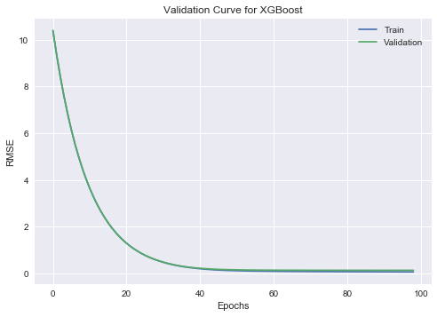

```python
model = xgb.XGBRegressor(
     learning_rate=0.1,
     n_estimators=150,
     max_depth=5,
     min_child_weight=5,
     gamma=0,
     subsample=0.6,
     colsample_bytree=0.8,
     n_jobs=2,
     scale_pos_weight=1,
     reg_alpha=0.005,
     random_state=42)

early_stopping_rounds = 10

#Fit the algorithm on the data
eval_set = [(x_train, y_train),(x_validation, y_validation)]
model.fit(x_train, y_train, early_stopping_rounds=early_stopping_rounds, eval_metric='rmse', eval_set=eval_set, verbose=False)


# make predictions for test data
y_train_pred = model.predict(x_train)
y_test_pred = [value for value in y_train_pred]
# evaluate predictions
y_train_real = np.expm1(y_train.values)
y_train_pred = np.expm1(y_train_pred)
print("train RMSE: %f" % (np.sqrt(mean_squared_error(y_train_real, y_train_pred))))

# make predictions for test data
y_validation_pred = model.predict(x_validation)
y_validation_pred = [value for value in y_validation_pred]
# evaluate predictions
y_validation_real = np.expm1(y_validation.values)
y_validation_pred = np.expm1(y_validation_pred)
print("validation RMSE: %f" % (np.sqrt(mean_squared_error(y_validation_real, y_validation_pred))))


results = model.evals_result()

# retrieve performance metrics
epochs = len(results['validation_0']['rmse'])
x_axis = range(0, epochs)

# plot curve
fig, ax = plt.subplots()
ax.plot(x_axis, results['validation_0']['rmse'], label='Train')
ax.plot(x_axis, results['validation_1']['rmse'], label='Validation')
ax.legend()
plt.xlabel('Epochs')
plt.ylabel('RMSE')
plt.title('Validation Curve for XGBoost')
plt.show()
```

### Final model

Finalizing the model involves fitting the final model on on the entire train dataset and saving the model for later use.

```python
model = xgb.XGBRegressor(
     learning_rate=0.1,
     n_estimators=150,
     max_depth=5,
     min_child_weight=5,
     gamma=0,
     subsample=0.6,
     colsample_bytree=0.8,
     n_jobs=2,
     scale_pos_weight=1,
     reg_alpha=0.005,
     random_state=42)

# Save final model (combine train and validation)
model.fit(X, Y, eval_metric='rmse')

# save model to file
joblib.dump(model, "output/xgboost.dat")
```

```
['output/xgboost.dat']
```

### Model validation

```python
# load model from file
loaded_model = joblib.load("output/xgboost.dat")

# load test data
test = pd.read_csv("processed/test+dummy+log+minmax.csv")

y_test = test['SalePrice']
x_test = test.drop('SalePrice', axis=1)

# make predictions for test data
y_test_pred = loaded_model.predict(x_test)
y_test_pred = [value for value in y_test_pred]
# evaluate predictions
y_test_real = np.expm1(y_test.values)
y_test_pred = np.expm1(y_test_pred)
print("test RMSE: %f" % (np.sqrt(mean_squared_error(y_test_real, y_test_pred))))
```

```
test RMSE: 26333.983839
```

## 6. Conclusion

This project predicted the sale price of residential houses in Ames, Lowa. It is observed that there is no a very big leap in performance by just using parameter tuning. The model can be further improved by other methods like feature engineering, creating ensemble of models and stacking.